# The Evolution of Popular Music over Recent Years

# The Titans of Popular Music

Here, we get all of the artists with 10 or more top 100 songs.

```python
data.head()
topArt = data['artist'].value_counts().to_frame(name='Num_Songs')
topArt = topArt.loc[topArt['Num_Songs'] > 9]
artID = []
genres = []
for i,row in topArt.iterrows():
    result = sp.search(q=i,type='artist')
    artID.append(result['artists']['items'][0]['id'])
    genres.append(result['artists']['items'][0]['genres'])
```

```python
topArt['artID'] = artID
topArt['genres'] = genres

topArt
```

|  | Num_Songs | artID | genres |
| --- | --- | --- | --- |
| Madonna | 35 | 6tbjWDEIzxoDsBA1FuhfPW | [dance pop, pop] |
| Elton John | 26 | 3PhoLpVuITZKcymswpck5b | [glam rock, mellow gold, piano rock] |
| Janet Jackson | 24 | 4qwGe91Bz9K2T8jXTZ815W | [dance pop, hip pop, neo soul, new jack swing,... |
| Mariah Carey | 23 | 4iHNK0tOyZPYnBU7nGAgpQ | [dance pop, pop, r&b, urban contemporary] |
| Michael Jackson | 22 | 3fMbdgg4jU18AjLCKBhRSm | [pop, r&b, soul] |
| Taylor Swift | 20 | 06HL4z0CvFAxyc27GXpf02 | [pop, post-teen pop] |
| Whitney Houston | 19 | 6XpaIBNiVzIetEPCWDvAFP | [dance pop, pop, r&b] |
| Pink | 18 | 0k17h0D3J5VfsdmQ1iZtE9 | [album rock, art rock, classic rock, progressi... |
| Hall & Oates | 17 | 77tT1kLj6mCWtFNqiOmP9H | [album rock, classic rock, mellow gold, rock, ... |
| Stevie Wonder | 17 | 7guDJrEfX3qb6FEbdPA5qi | [adult standards, motown, quiet storm, soul] |
| Rihanna | 16 | 5pKCCKE2ajJHZ9KAiaK11H | [barbadian pop, dance pop, pop, post-teen pop,... |
| The Black Eyed Peas | 16 | 1yxSLGMDHlW21z4YXirZDS | [dance pop, pop, pop rap] |
| Britney Spears | 16 | 26dSoYclwsYLMAKD3tpOr4 | [dance pop, pop, post-teen pop] |
| Drake | 16 | 3TVXtAsR1Inumwj472S9r4 | [canadian hip hop, canadian pop, hip hop, pop ... |
| Kelly Clarkson | 15 | 3BmGtnKgCSGYIUhmivXKWX | [dance pop, neo mellow, pop, pop rock, post-te... |
| Beyoncé | 13 | 6vWDO969PvNqNYHIOW5v0m | [dance pop, pop, pop rap, r&b] |
| R. Kelly | 13 | 2mxe0TnaNL039ysAj51xPQ | [] |
| Boyz II Men | 13 | 6O74knDqdv3XaWtkII7Xjp | [boy band, new jack swing, pop, quiet storm, r... |
| Rod Stewart | 13 | 2y8Jo9CKhJvtfeKOsYzRdT | [adult standards, mellow gold, soft rock] |
| Phil Collins | 13 | 4lxfqrEsLX6N1N4OCSkILp | [mellow gold, soft rock] |
| Chicago | 13 | 3iDD7bnsjL9J4fO298r0L0 | [adult standards, album rock, classic rock, fo... |
| Olivia Newton-John | 12 | 4BoRxUdrcgbbq1rxJvvhg9 | [adult standards, australian dance, bubblegum ... |
| Lionel Richie | 12 | 3gMaNLQm7D9MornNILzdSl | [adult standards, disco, mellow gold, motown, ... |
| Kool & the Gang | 12 | 3VNITwohbvU5Wuy5PC6dsI | [disco, funk, motown, post-disco, quiet storm,... |
| Aerosmith | 12 | 7Ey4PD4MYsKc5I2dolUwbH | [album rock, classic rock, hard rock, rock] |
| Usher | 12 | 23zg3TcAtWQy7J6upgbUnj | [atl hip hop, dance pop, pop, pop rap, r&b, ur... |
| Bee Gees | 12 | 1LZEQNv7sE11VDY3SdxQeN | [adult standards, disco, mellow gold, soft rock] |
| Billy Joel | 12 | 6zFYqv1mOsgBRQbae3JJ9e | [album rock, classic rock, folk rock, mellow g... |
| Bryan Adams | 11 | 3Z02hBLubJxuFJfhacLSDc | [album rock, canadian pop, canadian singer-son... |
| Aaliyah | 11 | 0urTpYCsixqZwgNTkPJOJ4 | [dance pop, hip hop, hip pop, pop, pop rap, r&... |
| Nickelback | 11 | 6deZN1bslXzeGvOLaLMOIF | [alternative metal, canadian rock, nu metal, p... |
| Destiny's Child | 11 | 1Y8cdNmUJH7yBTd9yOvr5i | [dance pop, girl group, hip pop, pop, pop rap,... |
| George Michael | 11 | 19ra5tSw0tWufvUp8GotLo | [dance rock, europop, new wave pop, soft rock] |
| Barry Manilow | 11 | 3alW3LYQS8K29z8C8NSLIX | [adult standards, bubblegum pop, disco, lounge... |
| Duran Duran | 11 | 0lZoBs4Pzo7R89JM9lxwoT | [dance rock, new romantic, new wave, new wave ... |
| Eminem | 11 | 7dGJo4pcD2V6oG8kP0tJRR | [detroit hip hop, g funk, hip hop, rap] |
| TLC | 10 | 0TImkz4nPqjegtVSMZnMRq | [atl hip hop, dance pop, girl group, hip hop, ... |
| Fleetwood Mac | 10 | 08GQAI4eElDnROBrJRGE0X | [album rock, classic rock, mellow gold, rock, ... |
| Diana Ross | 10 | 3MdG05syQeRYPPcClLaUGl | [adult standards, disco, funk, mellow gold, mo... |
| Michael Bolton | 10 | 6YHEMoNPbcheiWS2haGzkn | [adult standards, soft rock] |
| Bon Jovi | 10 | 58lV9VcRSjABbAbfWS6skp | [glam metal, rock] |
| Alicia Keys | 10 | 3DiDSECUqqY1AuBP8qtaIa | [hip pop, neo soul, pop, r&b, urban contemporary] |
| Katy Perry | 10 | 6jJ0s89eD6GaHleKKya26X | [dance pop, pop, post-teen pop] |
| Huey Lewis and the News | 10 | 7A9yZMTrFZcgEWAX2kBfK6 | [album rock, classic rock, dance rock, folk ro... |
| Richard Marx | 10 | 0grdhNhiRLFBaFVyybqsj6 | [mellow gold, new wave pop, soft rock] |
| Donna Summer | 10 | 2eogQKWWoohI3BSnoG7E2U | [dance pop, disco, europop, hi-nrg, motown, ne... |
| Genesis | 10 | 3CkvROUTQ6nRi9yQOcsB50 | [album rock, art rock, classic rock, mellow go... |

Here we made a word cloud to show us want type of genres the the titans of popular music are associated with. By far, the biggest are pop and soft rock which is not surprising. Pop music being popular by definition and its sound changing throughout the decades as it finds new fans. Soft rock also being easy to listen too and uniting generations.

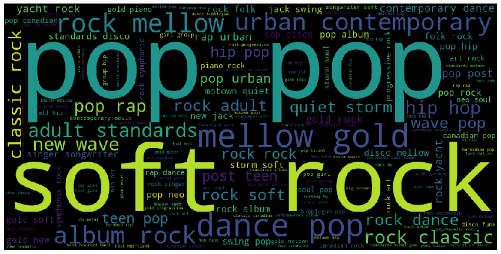

```python
topGen = []

for i,row in topArt.iterrows():
    curGen = topArt['genres']
    for cgen in curGen:
        for gen in cgen:
            topGen.append(gen)

unique_string=(" ").join(topGen)
wordcloud = WordCloud(width = 1000, height = 500).generate(unique_string)
plt.figure(figsize=(15,8))
plt.imshow(wordcloud)
plt.axis("off")
plt.savefig("your_file_name"+".png", bbox_inches='tight')
plt.show()
plt.close()
```

```python
topSongs = []

for i,row in topArt.iterrows():
    curArt = i
    for j,s in data.iterrows():
        if(s['artist'] == curArt):
            topSongs.append(s)
```

```python
songs = pd.DataFrame(topSongs)
songs = songs.reset_index()
songs = songs.drop('index',axis = 1)
songs.info()
```

```
<class 'pandas.core.frame.DataFrame'>
RangeIndex: 660 entries, 0 to 659
Data columns (total 22 columns):
artist              660 non-null object
song                660 non-null object
year                660 non-null int64
rank                660 non-null int64
danceability        660 non-null float64
energy              660 non-null float64
key                 660 non-null int64
loudness            660 non-null float64
mode                660 non-null int64
speechiness         660 non-null float64
acousticness        660 non-null float64
instrumentalness    660 non-null float64
liveness            660 non-null float64
valence             660 non-null float64
tempo               660 non-null float64
type_feature        660 non-null object
song_id             660 non-null object
uri                 660 non-null object
track_href          660 non-null object
analysis_url        660 non-null object
duration_ms         660 non-null int64
time_signature      660 non-null int64
dtypes: float64(9), int64(6), object(7)
memory usage: 113.6+ KB
```

# Madonna the leader of Billboards!

Madonna has 35 songs in the top 100, the next highest being Elton John with 26. Here, we will do some analysis on Madonna's potential influence on popular music.

Here we plot each of Madonna's songs' year and rank.

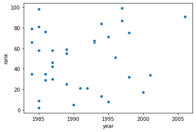

```python
madonna = songs.loc[songs['artist'] == 'Madonna']
sns.scatterplot(madonna['year'],madonna['rank'])
```

Here we can see that there is a weak correlation between danceability and time with Madonna's music.

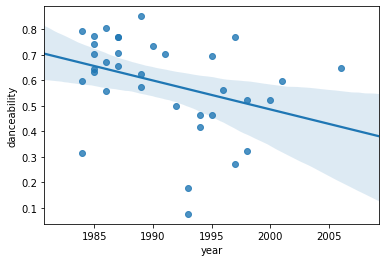

```python
sns.regplot(madonna['year'],madonna['danceability'])
```

Matching with the overall trend, Madonna's top music also has become less happy as years go by.

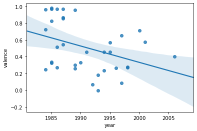

```python
sns.regplot(madonna['year'],madonna['valence'])
```

# Who is the Saddest and Happiest Artist?

Here we average the features of the top songs of the top artists as defined above.

```python
byArtist = songs.groupby('artist').mean()

byArtist.head()
```

| artist | year | rank | danceability | energy | key | loudness | mode | speechiness | acousticness | instrumentalness | liveness | valence | tempo | duration_ms | time_signature |
| --- | --- | --- | --- | --- | --- | --- | --- | --- | --- | --- | --- | --- | --- | --- | --- |
| Aaliyah | 1999.000000 | 61.636364 | 0.652091 | 0.651091 | 6.090909 | -7.409727 | 0.545455 | 0.066727 | 0.256221 | 0.016004 | 0.179691 | 0.617909 | 113.504091 | 223407.727273 | 4.000000 |
| Aerosmith | 1990.250000 | 64.333333 | 0.519000 | 0.739167 | 4.916667 | -6.158333 | 0.916667 | 0.045342 | 0.131327 | 0.010751 | 0.183417 | 0.455583 | 121.009000 | 255479.750000 | 4.000000 |
| Alicia Keys | 2005.900000 | 44.400000 | 0.569500 | 0.561900 | 4.700000 | -7.813200 | 0.700000 | 0.089570 | 0.301280 | 0.025084 | 0.128330 | 0.339100 | 105.503600 | 265208.800000 | 4.000000 |
| Barry Manilow | 1977.454545 | 60.454545 | 0.360909 | 0.470727 | 3.818182 | -8.803091 | 0.727273 | 0.035918 | 0.572182 | 0.004115 | 0.137255 | 0.325973 | 113.660000 | 247465.454545 | 3.909091 |
| Bee Gees | 1976.416667 | 30.083333 | 0.619917 | 0.587167 | 6.000000 | -9.521667 | 0.500000 | 0.045708 | 0.190828 | 0.023787 | 0.246458 | 0.690333 | 113.605750 | 260175.000000 | 3.916667 |

Mode is a feature for a song that is either 0 or 1 indicating weather a song is either major or minor. Major songs are happier and uplifting while minor songs are usually sad and more "heavy". For more reading on the difference between the two, here is a link. https://www.musical-u.com/learn/major-minor-keys/

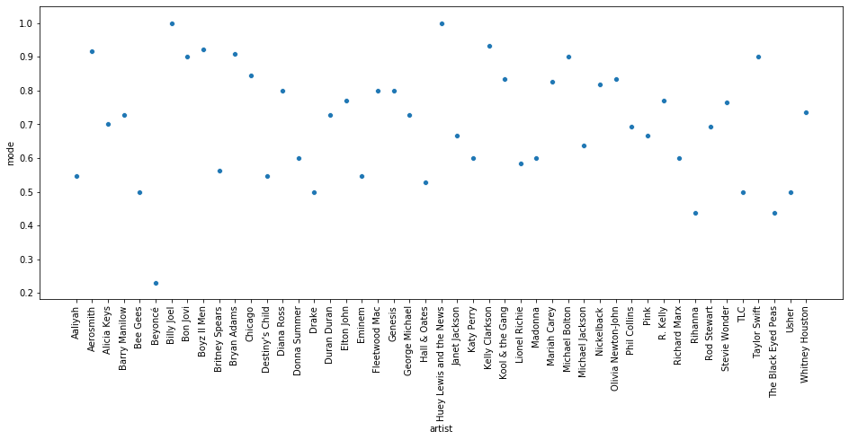

```python
plt.figure(figsize=(16, 6))
plt.xticks(rotation=90)
sns.scatterplot(byArtist.index,byArtist['mode'])
```

Billy Joel and Huey Lewis and the News fill the world with feel good sing a long songs. Personally I have to give the edge to Billy Joel because Huey's early music was a little to new wave for my taste.

Beyonce on the other hand is the Queen of sad girl music. With 80% of her most popular songs being in a minor key Beyonce is bringing the world together to cry.

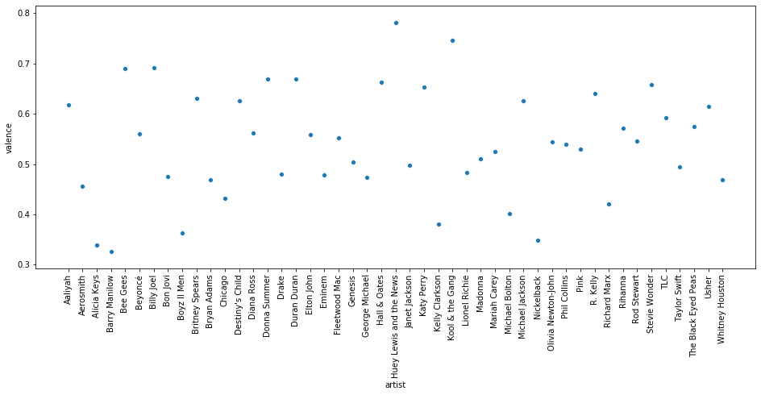

```python
plt.figure(figsize=(16, 6))
plt.xticks(rotation=90)
sns.scatterplot(byArtist.index,byArtist['valence'])
```

[figure not shown]

```python
# Lets go Crazy
Image("huey.jpg")
```

Spotify has their own metric of how happy a song is called valence. Valence is "A measure from 0.0 to 1.0 describing the musical positiveness conveyed by a track. Tracks with high valence sound more positive (e.g. happy, cheerful, euphoric), while tracks with low valence sound more negative (e.g. sad, depressed, angry)"

Heuy Lewis is the king of bringing the world happy music. With almost all of their most popular songs rated as very happy with only one sad hit song. The masses of fans came to expect this sound from them with only one of their ten songs to crack the billboard top 100 being rated viewed as sad.

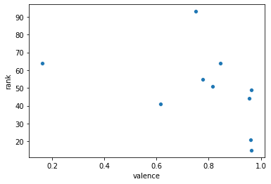

```python
huey = songs.loc[songs['artist'] == 'Huey Lewis and the News']
sns.scatterplot(huey['valence'],huey['rank'])
```

On the other hand Alicia Keys, Barry Manilow, Boyz II Men, and Nickelback are all about producing sad hits.

Barry Manilow hits the lowest lows and while he manages to break into the top 100 doesnt have as high hits as his competitors

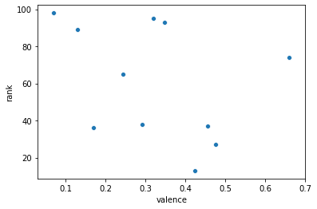

```python
art = songs.loc[songs['artist'] == 'Barry Manilow']
sns.scatterplot(art['valence'],art['rank'])
```

While Nickelback is comfortably making some sad hits their most popular songs are actually their somewhat happy songs

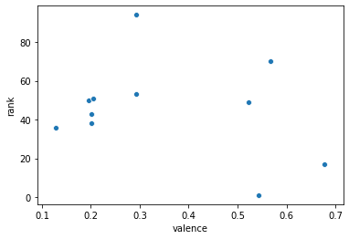

```python
art = songs.loc[songs['artist'] == 'Nickelback']
sns.scatterplot(art['valence'],art['rank'])
```

Lets see if they noticed this and changed their sound. And the answer is no, Nickelback does not learn.

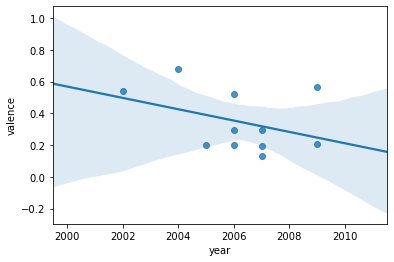

```python
sns.regplot(art['year'],art['valence'])
```

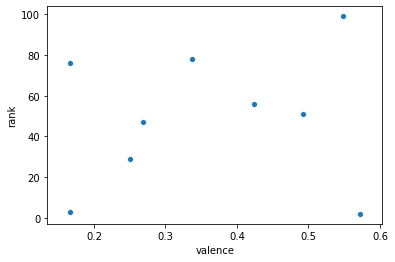

```python
art = songs.loc[songs['artist'] == 'Alicia Keys']
sns.scatterplot(art['valence'],art['rank'])
```

Boyz II Men also have a wide range of popular music. Boyz II Men seemed to learn that their sad songs were the most popular and focused on making the best of their sad songs later in their career.

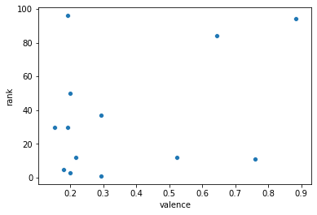

```python
art = songs.loc[songs['artist'] == 'Boyz II Men']
sns.scatterplot(art['valence'],art['rank'])
```

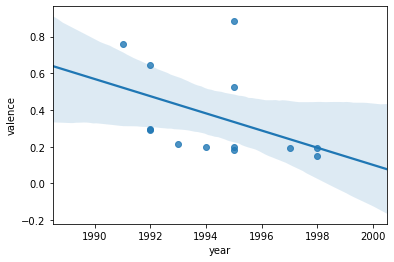

```python
sns.regplot(art['year'],art['valence'])
```

# When was it easiest to dominate the Billboard?

To answer this question we will first make a scatter plot of the number of songs to make the top 100 vs the average year a top 100 song was released for an artist. From this we can see that the leaders of the titans are concentrated in between 1985 - 1995.

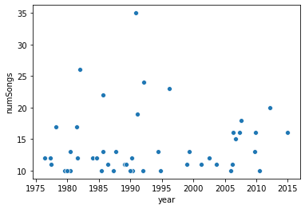

```python
byArtist['numSongs'] = topArt['Num_Songs']

sns.scatterplot(byArtist['year'],byArtist['numSongs'])
```

Next we will make a plot of the average rank of a top 100 song by an artist vs the average year a top 100 song was released by an artist. Here we can see that between 1990 - 1996, five different artists were able to consistently release songs that cracked the top 40.

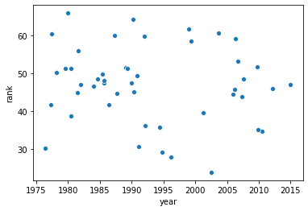

```python
sns.scatterplot(byArtist['year'],byArtist['rank'])
```

This is also when song lengths hit their zenith maybe allowing to artists to fully express their creativity in length. This era also represents a cross roads in music culture outside of the top 100 with the rise of the golden age of rap and grunge mixed with the ending of dominance of hair metal bands from the 80s.

## Insights and Conclusion

One of the most significant trends that we noticed over time was the change in "happiness." Happiness of a song is measured by two metrics: the valence and the mode (mode can also be further distinguished by key, but we won't get into that). As we saw with the regression of valence and mode with time, songs have gotten "sadder," meaning that their valence and mode has decreased on average.

Another trend that we noticed was the decrease in average acousticness of songs; by definition, a song is less acoustic if it uses more electrical amplification. We can attribute the decrease in acousticness to the increased use of synthesizers in popular songs rather than actual instruments. However, it is important note, that while popular songs may still use instruments, synthesizers and other tools are used to modify the song and affect its acousticness.

Additionally, songs have become louder on average. This is due to "dynamic range compression," which is a technique used by producers and audio engineers to boost quieter parts of songs.

Overall, we have found that songs have become more danceable, louder, shorter, and sadder. If you want to make a hit song in this day and age, make short, sad song with sick beat -- and watch out for the return of punk music!